# Income Prediction for Targeted Marketing

Scott Silverstein

2024-04-26

```r
library(data.table)
library(tidyverse)
```

```r
library(ggplot2)
library(psych)
library(moments)
library(knitr)
library(kableExtra)
library(ROSE)
library(caret)
library(rpart)
library(rpart.plot)
library(class)
library(lime)
library(pROC)
library(arules)
library(arulesViz)
library(Matrix)
library(e1071)
library(Metrics)
library(rminer)
library(rmarkdown)
library(matrixStats)
```

== Requirements

# Exploratory Data Analysis (EDA)**:

```r
census <- read.csv("census.csv")
```

## Data overview

```r
head(census)
```

```
##   age         workclass fnlwgt  education education.num      marital.status
## 1  39         State-gov  77516  Bachelors            13       Never-married
## 2  50  Self-emp-not-inc  83311  Bachelors            13  Married-civ-spouse
## 3  38           Private 215646    HS-grad             9            Divorced
## 4  53           Private 234721       11th             7  Married-civ-spouse
## 5  28           Private 338409  Bachelors            13  Married-civ-spouse
## 6  37           Private 284582    Masters            14  Married-civ-spouse
##           occupation   relationship   race     sex capital.gain capital.loss
## 1       Adm-clerical  Not-in-family  White    Male         2174            0
## 2    Exec-managerial        Husband  White    Male            0            0
## 3  Handlers-cleaners  Not-in-family  White    Male            0            0
## 4  Handlers-cleaners        Husband  Black    Male            0            0
## 5     Prof-specialty           Wife  Black  Female            0            0
## 6    Exec-managerial           Wife  White  Female            0            0
##   hours.per.week native.country      y
## 1             40  United-States  <=50K
## 2             13  United-States  <=50K
## 3             40  United-States  <=50K
## 4             40  United-States  <=50K
## 5             40           Cuba  <=50K
## 6             40  United-States  <=50K
```

```r
str(census)
```

```
## 'data.frame':    32561 obs. of  15 variables:
##  $ age           : int  39 50 38 53 28 37 49 52 31 42 ...
##  $ workclass     : chr  " State-gov" " Self-emp-not-inc" " Private" " Private" ...
##  $ fnlwgt        : int  77516 83311 215646 234721 338409 284582 160187 209642 45781 159449 ...
##  $ education     : chr  " Bachelors" " Bachelors" " HS-grad" " 11th" ...
##  $ education.num : int  13 13 9 7 13 14 5 9 14 13 ...
##  $ marital.status: chr  " Never-married" " Married-civ-spouse" " Divorced" " Married-civ-spouse" ...
##  $ occupation    : chr  " Adm-clerical" " Exec-managerial" " Handlers-cleaners" " Handlers-cleaners" ...
##  $ relationship  : chr  " Not-in-family" " Husband" " Not-in-family" " Husband" ...
##  $ race          : chr  " White" " White" " White" " Black" ...
##  $ sex           : chr  " Male" " Male" " Male" " Male" ...
##  $ capital.gain  : int  2174 0 0 0 0 0 0 0 14084 5178 ...
##  $ capital.loss  : int  0 0 0 0 0 0 0 0 0 0 ...
##  $ hours.per.week: int  40 13 40 40 40 40 16 45 50 40 ...
##  $ native.country: chr  " United-States" " United-States" " United-States" " United-States" ...
##  $ y             : chr  " <=50K" " <=50K" " <=50K" " <=50K" ...
```

## NA’s

```r
sapply(census, function(x) sum(is.na(x)))
```

```
##            age      workclass         fnlwgt      education  education.num
##              0              0              0              0              0
## marital.status     occupation   relationship           race            sex
##              0              0              0              0              0
##   capital.gain   capital.loss hours.per.week native.country              y
##              0              0              0              0              0
```

## Target Variable

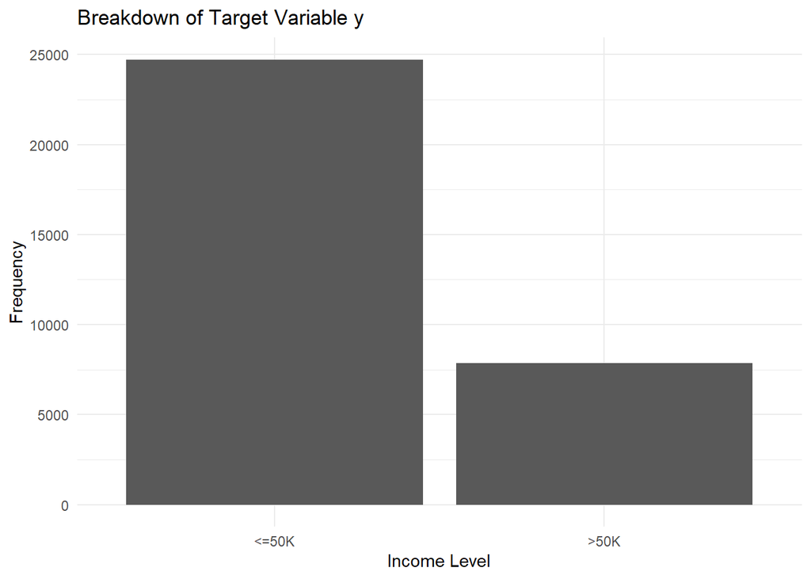

```r
census$y <- as.factor(census$y)

# Create a bar chart for the target variable 'y'
ggplot(census, aes(x=y)) +
  geom_bar() +
  theme_minimal() +
  labs(title = 'Breakdown of Target Variable y',
       x = 'Income Level',
       y = 'Frequency') +
  scale_x_discrete(labels = c('<=50K', '>50K'))
```

The bar chart presents a clear visualization of the target variable y, which categorizes individuals into two income groups: those earning <=50K and those earning >50K. There is a pronounced class imbalance evident, with a substantially larger number of individuals falling into the <=50K income bracket. This imbalance highlights the predominance of lower-income individuals in the dataset, which may affect the performance of predictive models—models may become biased toward predicting the majority class. For future modeling, this suggests the need to consider techniques such as oversampling the minority class, undersampling the majority class, or applying algorithms that are less sensitive to class imbalance to ensure a fair and accurate prediction for both income levels.

## Descriptive Stats

```r
numerical_summary <- census %>%
  select_if(is.numeric) %>%
  summarise(across(everything(), list(
    min = ~min(.), max = ~max(.), mean = ~mean(., na.rm = TRUE),
    median = ~median(., na.rm = TRUE), variance = ~var(., na.rm = TRUE),
    sd = ~sd(., na.rm = TRUE), IQR = ~IQR(., na.rm = TRUE),
    skewness = ~skewness(., na.rm = TRUE), kurtosis = ~kurtosis(., na.rm = TRUE)
  )))
numerical_summary_table <- kable(numerical_summary, format = "html", caption = "Descriptive Statistics for Numerical Features")


numerical_summary_table <- numerical_summary_table %>%
  kable_styling(bootstrap_options = c("striped", "hover", "condensed", "responsive"))

# Print the table
numerical_summary_table
```

Descriptive Statistics for Numerical Features

| age_min | age_max | age_mean | age_median | age_variance | age_sd | age_IQR | age_skewness | age_kurtosis | fnlwgt_min | fnlwgt_max | fnlwgt_mean | fnlwgt_median | fnlwgt_variance | fnlwgt_sd | fnlwgt_IQR | fnlwgt_skewness | fnlwgt_kurtosis | education.num_min | education.num_max | education.num_mean | education.num_median | education.num_variance | education.num_sd | education.num_IQR | education.num_skewness | education.num_kurtosis | capital.gain_min | capital.gain_max | capital.gain_mean | … |
| --- | --- | --- | --- | --- | --- | --- | --- | --- | --- | --- | --- | --- | --- | --- | --- | --- | --- | --- | --- | --- | --- | --- | --- | --- | --- | --- | --- | --- | --- | --- |
| 17 | 90 | 38.58165 | 37 | 186.0614 | 13.64043 | 20 | 0.5586919 | -0.1664603 | 12285 | 1484705 | 189778.4 | 178356 | 11140797792 | 105550 | 119224 | 1.446847 | 6.217106 | 1 | 16 | 10.08068 | 10 | 6.61889 | 2.57272 | 3 | -0.3116472 | 0.6229415 | 0 | 99999 | 1077.649 | … |

The statistical summary of the census data offers a revealing snapshot across multiple key numerical attributes. Starting with age, the range spans from 17 to 90 years, with a mean slightly above the median, indicating a young to middle-aged skewed distribution and a moderate spread around the mean as shown by a standard deviation of approximately 13.64. The final weight (fnlwgt) variable, likely a sampling weight, shows a wide range and a high degree of variance, suggesting substantial differences across the sampled individuals. The education.num feature, possibly representing years of education, spans from 1 to 16, with a mean and median around 10, hinting at a high-school level education being most common. Capital gain and capital loss variables display a large range, but the mean and median close to zero suggest that high values are rare occurrences. Finally, the hours per week worked range from 1 to 99, with a mean and median around 40, indicating a standard full-time work schedule, yet the presence of high skewness and kurtosis indicate that there are individuals working significantly more or less than this average. Overall, these statistics provide crucial insights into the demographic and socio-economic structure of the population in the dataset, which is vital for informed model building and interpretation.

## Distribution of numeric variables

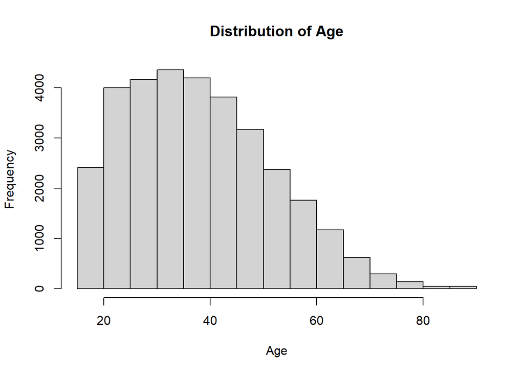

```r
hist(census$age, main = "Distribution of Age", xlab = "Age")
```

The age distribution is right-skewed, indicating that a larger proportion of the population falls within the younger age brackets. The majority of individuals are between 20 to 40 years old, with the frequency gradually decreasing for older age groups. This suggests that the dataset likely represents a working-age population with fewer older adults, which could be reflective of the general workforce demographic. The data also shows a considerable decline in frequency past the age of 60, which might correspond to the typical retirement age.

## Pairs Panels

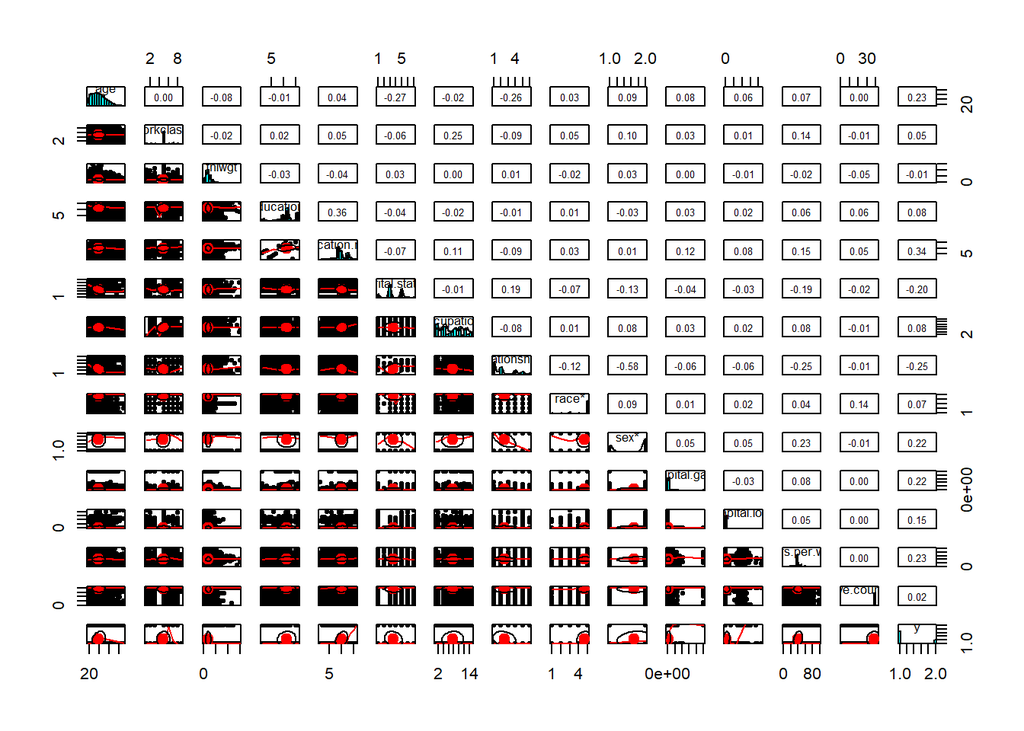

```r
pairs.panels(census)
```

## Model Selection

Given the fact that the target variable is categorical and we need to focus on the interpretability of the model, the choices we have eliminate almost all of the blackbox methods. As KNN and SVM might be great in terms of getting a great model, it is hard to describe what factors are leading to income.

This being said the models that would help is most certainly any decision tree such as rpart, logistical regression, naive Bayesian, and assocation rules. Turning all of the data into transactions for the arules might be challenging however.

# Data Preparation**: Prepare the data for modeling by cleaning, transforming, and encoding the necessary features to ensure the models operate efficiently and effectively.

## Transforming character variables to factors

```r
character_vars <- sapply(census, is.character)
census[character_vars] <- lapply(census[character_vars], as.factor)
```

## Handling class imbalance

```r
balanced_data <- ROSE(y ~ ., data = census)$data
prop.table(table(balanced_data$y))
```

```
##
##     <=50K      >50K
## 0.4996161 0.5003839
```

## Feature Scaling

```r
num_vars <- sapply(balanced_data, is.numeric)
preproc <- preProcess(balanced_data[, num_vars], method = c("center", "scale"))
balanced_data[, num_vars] <- predict(preproc, balanced_data[, num_vars])
```

```r
summary_before_scaling <- summary(census[, num_vars])

# After scaling the data
summary_after_scaling <- summary(balanced_data[, num_vars])

# Display both sets of summary statistics for comparison
comparison <- list(BeforeScaling = summary_before_scaling, AfterScaling = summary_after_scaling)
print(comparison)
```

```
## $BeforeScaling
##       age            fnlwgt        education.num    capital.gain
##  Min.   :17.00   Min.   :  12285   Min.   : 1.00   Min.   :    0
##  1st Qu.:28.00   1st Qu.: 117827   1st Qu.: 9.00   1st Qu.:    0
##  Median :37.00   Median : 178356   Median :10.00   Median :    0
##  Mean   :38.58   Mean   : 189778   Mean   :10.08   Mean   : 1078
##  3rd Qu.:48.00   3rd Qu.: 237051   3rd Qu.:12.00   3rd Qu.:    0
##  Max.   :90.00   Max.   :1484705   Max.   :16.00   Max.   :99999
##   capital.loss    hours.per.week
##  Min.   :   0.0   Min.   : 1.00
##  1st Qu.:   0.0   1st Qu.:40.00
##  Median :   0.0   Median :40.00
##  Mean   :  87.3   Mean   :40.44
##  3rd Qu.:   0.0   3rd Qu.:45.00
##  Max.   :4356.0   Max.   :99.00
##
## $AfterScaling
##       age               fnlwgt        education.num      capital.gain
##  Min.   :-2.79563   Min.   :-2.7357   Min.   :-4.0640   Min.   :-2.008077
##  1st Qu.:-0.74099   1st Qu.:-0.6710   1st Qu.:-0.6006   1st Qu.:-0.218892
##  Median :-0.04847   Median :-0.1039   Median :-0.1192   Median :-0.174752
##  Mean   : 0.00000   Mean   : 0.0000   Mean   : 0.0000   Mean   : 0.000000
##  3rd Qu.: 0.66623   3rd Qu.: 0.5111   3rd Qu.: 0.7940   3rd Qu.: 0.008473
##  Max.   : 4.32176   Max.   :11.6366   Max.   : 3.0185   Max.   :10.621045
##   capital.loss       hours.per.week
##  Min.   :-2.448293   Min.   :-3.84778
##  1st Qu.:-0.419737   1st Qu.:-0.43679
##  Median :-0.214792   Median :-0.03382
##  Mean   : 0.000000   Mean   : 0.00000
##  3rd Qu.: 0.008501   3rd Qu.: 0.47329
##  Max.   : 8.739306   Max.   : 5.14536
```

## Test Set and Train set

```r
set.seed(123)
trainIndex <- createDataPartition(balanced_data$y, p = .8,
                                  list = FALSE,
                                  times = 1)
trainData <- balanced_data[trainIndex, ]
testData <- balanced_data[-trainIndex, ]
```

```r
cat("Number of observations in training data:", nrow(trainData), "\n")
```

```
## Number of observations in training data: 26050
```

```r
cat("Number of observations in testing data:", nrow(testData), "\n")
```

```
## Number of observations in testing data: 6511
```

# Model Selection**: Focus on selecting and building models that offer a balance between predictability and interpretability. Suitable models for this task include:

## Naive Bayesian

```r
# Manually calculate precision and recall
calc_precision <- function(predictions, actuals) {
  tp <- sum(predictions == actuals & actuals == levels(actuals)[2])
  fp <- sum(predictions != actuals & actuals == levels(actuals)[1])
  if (tp + fp == 0) return(0)  # Avoid division by zero
  return(tp / (tp + fp))
}

calc_recall <- function(predictions, actuals) {
  tp <- sum(predictions == actuals & actuals == levels(actuals)[2])
  fn <- sum(predictions != actuals & actuals == levels(actuals)[2])
  if (tp + fn == 0) return(0)  # Avoid division by zero
  return(tp / (tp + fn))
}

calc_f1_score <- function(predictions, actuals) {
  precision <- calc_precision(predictions, actuals)
  recall <- calc_recall(predictions, actuals)
  if (precision + recall == 0) return(0)  # Avoid division by zero
  return(2 * precision * recall / (precision + recall))
}

cv_function <- function(df, target_index, nFolds, seedVal, classification_func, metrics_list) {
  set.seed(seedVal)
  folds <- createFolds(df[[target_index]], k = nFolds, list = TRUE)

  cv_results <- lapply(folds, function(fold_indices) {
    train_indices <- setdiff(seq_len(nrow(df)), fold_indices)
    test_indices <- fold_indices

    train <- df[train_indices, -target_index, drop = FALSE]
    test <- df[test_indices, -target_index, drop = FALSE]

    train_target <- df[train_indices, target_index]
    test_target <- df[test_indices, target_index]

    model <- classification_func(x = train, y = train_target)
    predictions <- predict(model, test)

    metrics_data <- list()
    if ("ACC" %in% metrics_list) {
      acc <- mean(predictions == test_target)
      names(acc) <- "ACC"
      metrics_data[["ACC"]] <- acc
    }
    if ("PRECISION" %in% metrics_list) {
      precision <- calc_precision(predictions, test_target)
      names(precision) <- "PRECISION"
      metrics_data[["PRECISION"]] <- precision
    }
    if ("TPR" %in% metrics_list) {
      tpr <- calc_recall(predictions, test_target)
      names(tpr) <- "TPR"
      metrics_data[["TPR"]] <- tpr
    }
    if ("F1" %in% metrics_list) {
      f1 <- calc_f1_score(predictions, test_target)
      names(f1) <- "F1"
      metrics_data[["F1"]] <- f1
    }

    return(metrics_data)
  })

  # Combine fold-specific metrics into a dataframe
  cv_results_df <- do.call(rbind, cv_results)

  return(cv_results_df)
}

# Example usage
metrics_list <- c("ACC", "PRECISION", "TPR", "F1")
cv_table <- cv_function(df = trainData,
                         target_index = ncol(trainData),
                         nFolds = 3,
                         seedVal = 1234,
                         classification_func = naiveBayes,
                         metrics_list = metrics_list)

# Print the CV table
print(cv_table)
```

```
##       ACC       PRECISION TPR       F1
## Fold1 0.8806864 0.9020656 0.8543153 0.8775414
## Fold2 0.8812759 0.9061275 0.8508631 0.8776261
## Fold3 0.8874813 0.9057831 0.8651323 0.8849912
```

Overall, these metrics indicate that the model performs well, with slight variations across different folds, which suggests some sensitivity to the data it is trained on. The consistent performance across all key metrics (ACC, Precision, TPR, and F1) suggests that the model is robust, but slight adjustments or additional training data might help stabilize performance across different subsets.

## Feature Importance

```r
feature_importance <- function(model) {
    feature_stats <- lapply(names(model$tables), function(feature) {
        # Extract the stats and ensure it's a data table
        stats <- as.data.table(model$tables[[feature]])

        # Ensure that values are numeric
        for (col in names(stats)) {
            if (!is.numeric(stats[[col]])) {
                stats[[col]] <- as.numeric(stats[[col]])
            }
        }

        stats[, feature := feature]  # Adding feature names as a column
        melted_stats <- melt(stats, id.vars = "feature", variable.name = "Class", value.name = "Probability")
        return(melted_stats)
    })

    # Combine all feature stats
    feature_stats <- do.call(rbind, feature_stats)
    # Calculate mean probabilities grouped by feature and class
    importance_data <- feature_stats[, .(MeanProbability = mean(Probability, na.rm = TRUE)), by = .(feature, Class)]
    return(importance_data)
}
target_column_index <- ncol(trainData)  # Last column as target
trainData$target <- factor(trainData[, target_column_index])  # Convert target to factor

# Train Naive Bayes model
model <- naiveBayes(target ~ ., data = trainData[, -target_column_index, drop = FALSE])
# Assuming model is already trained
importance_data <- feature_importance(model)
```

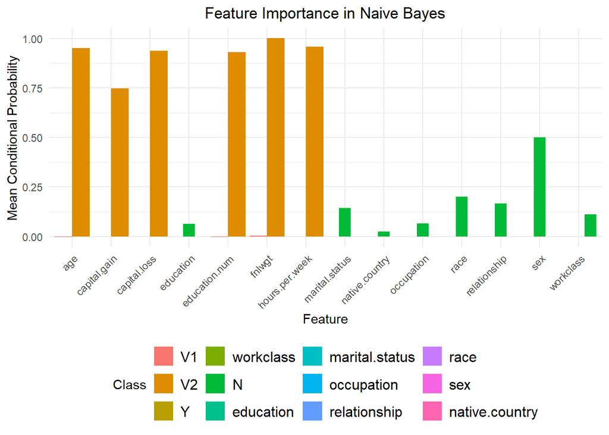

```r
# Plotting the feature importance
ggplot(importance_data, aes(x = feature, y = MeanProbability, fill = Class)) +
    geom_bar(stat = "identity", position = "dodge") +
    theme_minimal() +
    labs(title = "Feature Importance in Naive Bayes", x = "Feature", y = "Mean Conditional Probability") +
    theme(axis.text.x = element_text(angle = 45, vjust = 1, hjust=1),
          legend.position = "bottom",
          legend.text = element_text(size = 12),
          plot.title = element_text(hjust = 0.5))
```

## Decision Trees:

```r
# Building the decision tree model
decision_tree_model <- rpart(y ~ ., data = trainData, method = "class")

# Display the model output
print(decision_tree_model)
```

```
## n= 26050
##
## node), split, n, loss, yval, (yprob)
##       * denotes terminal node
##
## 1) root 26050 13015  >50K (0.4996161 0.5003839)
##   2) target= <=50K 13015     0  <=50K (1.0000000 0.0000000) *
##   3) target= >50K 13035     0  >50K (0.0000000 1.0000000) *
```

### Plotting

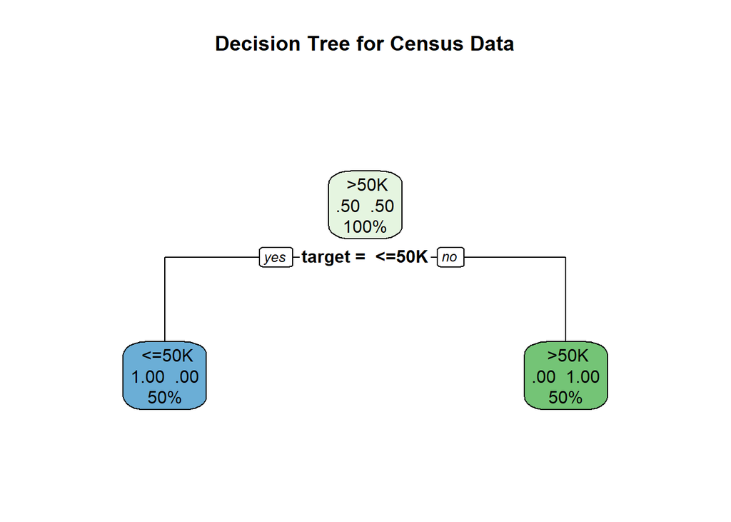

```r
# Plotting the decision tree
rpart.plot(decision_tree_model, main = "Decision Tree for Census Data", extra = 104)
```

## Logistic Regression: Provides a probabilistic approach for binary classification and yields interpretable results explaining the impact of predictor variables.

I am going to combine the information I learned for the rpart and the naive bayesian to make this model as solid as possible.

```r
log_model <- glm(y ~ capital.gain * capital.loss + capital.gain + capital.loss + education.num + hours.per.week,
                             family = binomial(link = "logit"),
                             data = trainData)
summary(log_model)
```

```
##
## Call:
## glm(formula = y ~ capital.gain * capital.loss + capital.gain +
##     capital.loss + education.num + hours.per.week, family = binomial(link = "logit"),
##     data = trainData)
##
## Coefficients:
##                           Estimate Std. Error z value Pr(>|z|)
## (Intercept)                0.06936    0.01462   4.743 2.11e-06 ***
## capital.gain               0.74497    0.03266  22.811  < 2e-16 ***
## capital.loss               0.26359    0.01721  15.316  < 2e-16 ***
## education.num              0.79529    0.01634  48.663  < 2e-16 ***
## hours.per.week             0.55556    0.01592  34.889  < 2e-16 ***
## capital.gain:capital.loss -0.17834    0.03538  -5.040 4.65e-07 ***
## ---
## Signif. codes:  0 '***' 0.001 '**' 0.01 '*' 0.05 '.' 0.1 ' ' 1
##
## (Dispersion parameter for binomial family taken to be 1)
##
##     Null deviance: 36113  on 26049  degrees of freedom
## Residual deviance: 29656  on 26044  degrees of freedom
## AIC: 29668
##
## Number of Fisher Scoring iterations: 5
```

```r
unique(trainData$y)
```

```
## [1]  <=50K  >50K
## Levels:  <=50K  >50K
```

```r
# Strip any leading/trailing white space
trainData$y <- trimws(trainData$y)
testData$y <- trimws(testData$y)

# Convert to factors with specified levels
trainData$y <- factor(trainData$y, levels = c("<=50K", ">50K"))
testData$y <- factor(testData$y, levels = c("<=50K", ">50K"))
```

## Metrics

```r
predicted_probs <- predict(log_model, newdata = testData, type = "response")
# Predict classes based on a threshold of 0.5
predicted_classes <- ifelse(predicted_probs > 0.5, " >50K", " <=50K")

# Create confusion matrix
conf_matrix <- table(Predicted = predicted_classes, Actual = testData$y)

# Calculate metrics
accuracy <- sum(diag(conf_matrix)) / sum(conf_matrix)
precision <- conf_matrix[2, 2] / sum(conf_matrix[2, ])
recall <- conf_matrix[2, 2] / sum(conf_matrix[, 2])
f1_score <- 2 * (precision * recall) / (precision + recall)

# Create a data frame for the table
metrics_df <- data.frame(
  Metric = c("Accuracy", "Precision", "Recall", "F1 Score"),
  Score = c(accuracy, precision, recall, f1_score)
)

# Print the table using knitr
knitr::kable(metrics_df, caption = "Model Performance Metrics", align = 'c')
```

Model Performance Metrics

| Metric | Score |
| --- | --- |
| Accuracy | 0.7213946 |
| Precision | 0.7320051 |
| Recall | 0.6992020 |
| F1 Score | 0.7152276 |

```r
log_model2 <- glm(y ~ (capital.gain + education.num + occupation + hours.per.week)^2,
                 family = binomial(link = "logit"),
                 data = trainData)
summary(log_model2)
```

```
##
## Call:
## glm(formula = y ~ (capital.gain + education.num + occupation +
##     hours.per.week)^2, family = binomial(link = "logit"), data = trainData)
##
## Coefficients:
##                                               Estimate Std. Error z value
## (Intercept)                                 -4.875e-01  9.032e-02  -5.398
## capital.gain                                 1.573e+00  2.377e-01   6.617
## education.num                                1.028e+00  9.176e-02  11.202
## occupation Adm-clerical                     -3.190e-02  1.024e-01  -0.312
## occupation Armed-Forces                     -2.157e+01  1.017e+03  -0.021
## occupation Craft-repair                      6.810e-01  1.007e-01   6.762
## occupation Exec-managerial                   1.360e+00  9.886e-02  13.760
## occupation Farming-fishing                  -2.123e-01  1.494e-01  -1.421
## occupation Handlers-cleaners                -4.694e-01  1.490e-01  -3.150
## occupation Machine-op-inspct                -4.285e-02  1.204e-01  -0.356
## occupation Other-service                    -8.759e-01  1.252e-01  -6.997
## occupation Priv-house-serv                  -1.012e+01  1.203e+02  -0.084
## occupation Prof-specialty                    9.175e-01  1.051e-01   8.733
## occupation Protective-serv                   1.190e+00  1.306e-01   9.113
## occupation Sales                             6.493e-01  9.989e-02   6.500
## occupation Tech-support                      7.248e-01  1.198e-01   6.052
## occupation Transport-moving                  4.044e-01  1.204e-01   3.359
## hours.per.week                               3.745e-01  6.412e-02   5.841
## capital.gain:education.num                  -6.691e-02  3.969e-02  -1.686
## capital.gain:occupation Adm-clerical        -4.685e-01  2.708e-01  -1.730
## capital.gain:occupation Armed-Forces        -4.930e+01  2.915e+03  -0.017
## capital.gain:occupation Craft-repair        -9.512e-01  2.542e-01  -3.742
## capital.gain:occupation Exec-managerial     -9.599e-01  2.479e-01  -3.872
## capital.gain:occupation Farming-fishing     -6.616e-01  3.198e-01  -2.069
## capital.gain:occupation Handlers-cleaners    8.145e-01  4.569e-01   1.783
## capital.gain:occupation Machine-op-inspct   -9.675e-01  3.071e-01  -3.150
## capital.gain:occupation Other-service       -4.574e-01  3.508e-01  -1.304
## capital.gain:occupation Priv-house-serv      1.914e+01  2.165e+02   0.088
## capital.gain:occupation Prof-specialty      -8.447e-01  2.499e-01  -3.380
## capital.gain:occupation Protective-serv     -1.173e+00  3.070e-01  -3.822
## capital.gain:occupation Sales               -7.777e-01  2.553e-01  -3.046
## capital.gain:occupation Tech-support        -1.163e+00  2.780e-01  -4.182
## capital.gain:occupation Transport-moving    -8.408e-01  2.871e-01  -2.928
```

[output cut: 89 more lines]

```
## occupation Prof-specialty:hours.per.week    0.595590
## occupation Protective-serv:hours.per.week   0.275650
## occupation Sales:hours.per.week             0.000255 ***
## occupation Tech-support:hours.per.week      0.924320
## occupation Transport-moving:hours.per.week  0.395284
## ---
## Signif. codes:  0 '***' 0.001 '**' 0.01 '*' 0.05 '.' 0.1 ' ' 1
##
## (Dispersion parameter for binomial family taken to be 1)
##
##     Null deviance: 36113  on 26049  degrees of freedom
## Residual deviance: 28051  on 25987  degrees of freedom
## AIC: 28177
##
## Number of Fisher Scoring iterations: 13
```